# Prediction Assignment

Paresh Pandey

10/4/2020

## Model Approach

### Data Partition

- Broke the training set provided into Train,Validate and Test
- Training data was split into Training and Test (80%-20%)
- Training was further split into Train and Validate (80%-20%), so eventually 64% of data was used for training while 16 % went for validation and 20% for Testing

### Model Approach

- Approach was to first build two models : Random Forest and Boosted Tree.
- Perform Model stacking of the above two models to see if Accuracy improves.

### Cross Validation

Five K-fold cross validation performed for both Random Forest and Boosted Trees

## Data Cleaning and Partition

```r
library(caret)
# Loading the data
pmltrainingset<-read.csv("pml-training.csv", na.strings=c("NA","#DIV/0!", ""))
pmltestset<-read.csv("pml-testing.csv" , na.strings=c("NA","#DIV/0!", ""))



# remove columns with NAs

pmltrainingset<-pmltrainingset[,colSums(is.na(pmltrainingset)) == 0]
pmltestset<-pmltestset[,colSums(is.na(pmltestset)) == 0]


# Removing columns like user name, time stamps etc.

pmltrainingset   <-pmltrainingset[,-c(1:7)]
pmltestset <-pmltestset[,-c(1:7)]


#breaking data into Training ,Validation and Test

set.seed(100)
trainindex<-createDataPartition(pmltrainingset$classe,p=0.8,list = FALSE)
pmltrainingTrain<-pmltrainingset[trainindex,]
pmltrainingTest<-pmltrainingset[-trainindex,]

set.seed(200)
trainindex2<-createDataPartition(pmltrainingTrain$classe,p=0.8,list = FALSE)
pmltrainingVal<-pmltrainingTrain[-trainindex2,]
pmltrainingTrain<-pmltrainingTrain[trainindex2,]
```

## Exploratory Data Analysis

```r
dim(pmltrainingset)
```

```
## [1] 19622    53
```

```r
str(pmltrainingTrain)
```

```
## 'data.frame':    12562 obs. of  53 variables:
##  $ roll_belt           : num  1.41 1.41 1.48 1.48 1.45 1.42 1.45 1.43 1.42 1.48 ...
##  $ pitch_belt          : num  8.07 8.07 8.05 8.07 8.06 8.09 8.17 8.18 8.21 8.15 ...
##  $ yaw_belt            : num  -94.4 -94.4 -94.4 -94.4 -94.4 -94.4 -94.4 -94.4 -94.4 -94.4 ...
##  $ total_accel_belt    : int  3 3 3 3 3 3 3 3 3 3 ...
##  $ gyros_belt_x        : num  0 0.02 0.02 0.02 0.02 0.02 0.03 0.02 0.02 0 ...
##  $ gyros_belt_y        : num  0 0 0 0.02 0 0 0 0 0 0 ...
##  $ gyros_belt_z        : num  -0.02 -0.02 -0.03 -0.02 -0.02 -0.02 0 -0.02 -0.02 0 ...
##  $ accel_belt_x        : int  -21 -22 -22 -21 -21 -22 -21 -22 -22 -21 ...
##  $ accel_belt_y        : int  4 4 3 2 4 3 4 2 4 4 ...
##  $ accel_belt_z        : int  22 22 21 24 21 21 22 23 21 23 ...
##  $ magnet_belt_x       : int  -3 -7 -6 -6 0 -4 -3 -2 -8 0 ...
##  $ magnet_belt_y       : int  599 608 604 600 603 599 609 602 598 592 ...
##  $ magnet_belt_z       : int  -313 -311 -310 -302 -312 -311 -308 -319 -310 -305 ...
##  $ roll_arm            : num  -128 -128 -128 -128 -128 -128 -128 -128 -128 -129 ...
```

[output cut: 39 more lines]

```r
table(pmltrainingTrain$classe)/length(pmltrainingTrain$classe)
```

```
##
##         A         B         C         D         E
## 0.2843496 0.1935201 0.1744149 0.1639070 0.1838083
```

Classes appear to be balanced.

## Model Creation

### Random Forest with 5 K-Fold cross validation

```r
control <- trainControl(method='cv',
                        number=5,
                        search = 'random')
set.seed(201)
rf_random <- train(classe ~ .,data = pmltrainingTrain,method = 'rf',        metric = 'Accuracy',tuneLength  = 15,trControl = control)


print(rf_random)
```

```
## Random Forest
##
## 12562 samples
##    52 predictor
##     5 classes: 'A', 'B', 'C', 'D', 'E'
##
## No pre-processing
## Resampling: Cross-Validated (5 fold)
## Summary of sample sizes: 10049, 10050, 10051, 10050, 10048
## Resampling results across tuning parameters:
##
##   mtry  Accuracy   Kappa
##    5    0.9914822  0.9892246
##    6    0.9917209  0.9895265
##    7    0.9921191  0.9900303
##   25    0.9900502  0.9874119
##   29    0.9887765  0.9858001
##   36    0.9872645  0.9838871
##   37    0.9871054  0.9836856
##   42    0.9858314  0.9820748
##   44    0.9859109  0.9821757
##   45    0.9847966  0.9807661
##   49    0.9836819  0.9793566
##   50    0.9836023  0.9792551
##
## Accuracy was used to select the optimal model using the largest value.
## The final value used for the model was mtry = 7.
```

Final model selected with mtry of 7. Accuracy and Kappa of final model are high at 0.9921191 and 0.9900303 respectively.

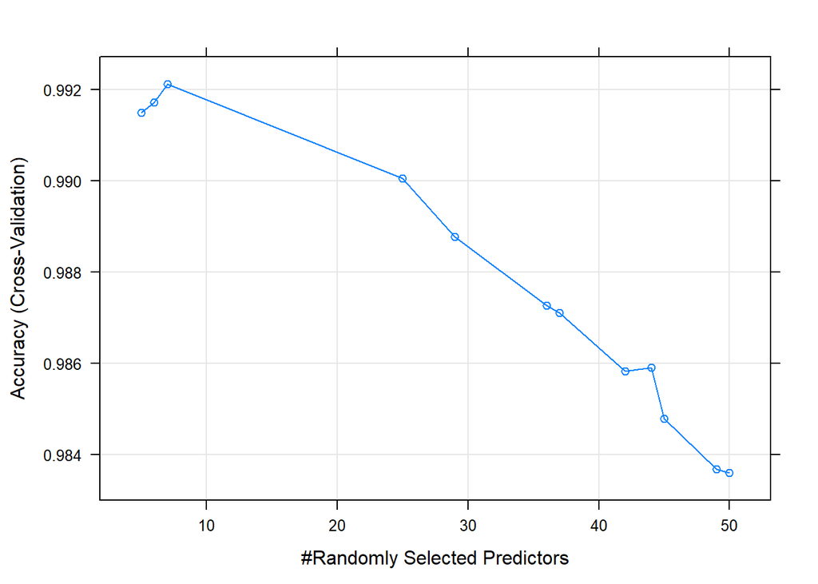

```r
plot(rf_random)
```

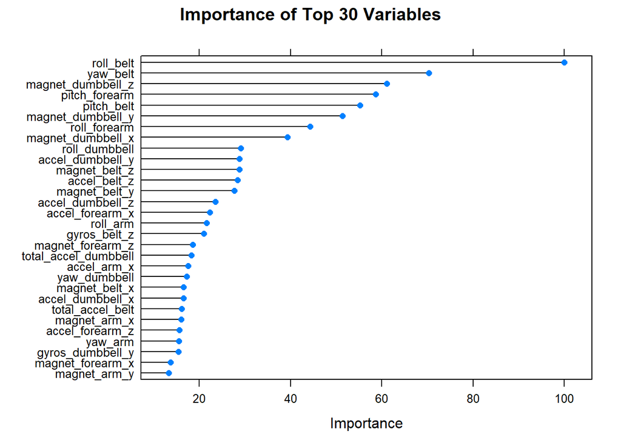

```r
Impobj<-varImp(rf_random)

plot(Impobj, main = "Importance of Top 30 Variables", top = 30)
```

Potential for optimization of predictors considered for model exists and a model with top 30 predictors can be tried for further tuning.

```r
cm<-rf_random$finalModel$confusion
cm <- cm[, -ncol(cm)]
1 - sum(diag(cm)) / sum(cm)
```

```
## [1] 0.005731571
```

OOB error estimate is 0.57% which is good.

### Boosted Tree with 5 K-Fold cross validation

```r
library(gbm)
control <- trainControl(method='cv',
                        number=5
                       )
set.seed(202)
tree_boost <- train(classe ~ .,data = pmltrainingTrain,method = 'gbm',trControl = control,verbose = FALSE)


print(tree_boost)
```

```
## Stochastic Gradient Boosting
##
## 12562 samples
##    52 predictor
##     5 classes: 'A', 'B', 'C', 'D', 'E'
##
## No pre-processing
## Resampling: Cross-Validated (5 fold)
## Summary of sample sizes: 10051, 10049, 10049, 10050, 10049
## Resampling results across tuning parameters:
##
##   interaction.depth  n.trees  Accuracy   Kappa
##   1                   50      0.7587963  0.6942381
##   1                  100      0.8228775  0.7757985
##   1                  150      0.8547195  0.8161650
##   2                   50      0.8541630  0.8151966
##   2                  100      0.9051896  0.8800175
##   2                  150      0.9307430  0.9123661
##   3                   50      0.9001752  0.8736540
##   3                  100      0.9409323  0.9252658
##   3                  150      0.9604353  0.9499452
##
## Tuning parameter 'shrinkage' was held constant at a value of 0.1
##
## Tuning parameter 'n.minobsinnode' was held constant at a value of 10
## Accuracy was used to select the optimal model using the largest value.
## The final values used for the model were n.trees = 150, interaction.depth =
##  3, shrinkage = 0.1 and n.minobsinnode = 10.
```

Final Model of interaction depth of 3 and ntrees of 150 was selected. Accuracy and Kappa of the model stand at 0.9604353 and 0.9499452 respectively which is lower than random forest.

## Validation set performance

### Random Forest Validation set performance

```r
predRF<- predict(rf_random,pmltrainingVal)

confusionMatrix(predRF,as.factor(pmltrainingVal$classe))
```

```
## Confusion Matrix and Statistics
##
##           Reference
## Prediction   A   B   C   D   E
##          A 891   1   0   0   0
##          B   1 606   3   0   0
##          C   0   0 544   4   0
##          D   0   0   0 510   1
##          E   0   0   0   0 576
##
## Overall Statistics
##
##                Accuracy : 0.9968
##                  95% CI : (0.9941, 0.9985)
##     No Information Rate : 0.2843
##     P-Value [Acc > NIR] : < 2.2e-16
##
##                   Kappa : 0.996
##
##  Mcnemar's Test P-Value : NA
##
## Statistics by Class:
##
##                      Class: A Class: B Class: C Class: D Class: E
## Sensitivity            0.9989   0.9984   0.9945   0.9922   0.9983
## Specificity            0.9996   0.9984   0.9985   0.9996   1.0000
## Pos Pred Value         0.9989   0.9934   0.9927   0.9980   1.0000
## Neg Pred Value         0.9996   0.9996   0.9988   0.9985   0.9996
## Prevalence             0.2843   0.1935   0.1744   0.1639   0.1839
## Detection Rate         0.2840   0.1932   0.1734   0.1626   0.1836
## Detection Prevalence   0.2843   0.1945   0.1747   0.1629   0.1836
## Balanced Accuracy      0.9992   0.9984   0.9965   0.9959   0.9991
```

Random Forest showed a good accuracy at 0.9968 .

### Boosted Tree Validation set performance

```r
predBoost<- predict(tree_boost,pmltrainingVal)

confusionMatrix(predBoost,as.factor(pmltrainingVal$classe))
```

```
## Confusion Matrix and Statistics
##
##           Reference
## Prediction   A   B   C   D   E
##          A 880  14   0   1   1
##          B   9 582  17   2  14
##          C   2  11 527  14   2
##          D   1   0   3 489  11
##          E   0   0   0   8 549
##
## Overall Statistics
##
##                Accuracy : 0.9649
##                  95% CI : (0.9579, 0.9711)
##     No Information Rate : 0.2843
##     P-Value [Acc > NIR] : < 2.2e-16
##
##                   Kappa : 0.9556
##
##  Mcnemar's Test P-Value : 0.0005948
##
## Statistics by Class:
##
##                      Class: A Class: B Class: C Class: D Class: E
## Sensitivity            0.9865   0.9588   0.9634   0.9514   0.9515
## Specificity            0.9929   0.9834   0.9888   0.9943   0.9969
## Pos Pred Value         0.9821   0.9327   0.9478   0.9702   0.9856
## Neg Pred Value         0.9946   0.9901   0.9923   0.9905   0.9891
## Prevalence             0.2843   0.1935   0.1744   0.1639   0.1839
## Detection Rate         0.2805   0.1855   0.1680   0.1559   0.1750
## Detection Prevalence   0.2856   0.1989   0.1772   0.1607   0.1776
## Balanced Accuracy      0.9897   0.9711   0.9761   0.9728   0.9742
```

Boosted Tree showed an accuracy of 0.9649 which is less than Random Forest

## Model Stacking of Random Forest and Boosted Tree models

```r
#creating a data fram of predicted values of RF and Boosted Tree along with
# classe

predDF<-data.frame(predrf=predRF,predboost=predBoost,classe=pmltrainingVal$classe)

set.seed(203)
Combinedmodelfit<-train(classe~.,method="rf",data = predDF)

predCombined<-predict(Combinedmodelfit,predDF)

confusionMatrix(predCombined,as.factor(pmltrainingVal$classe))
```

```
## Confusion Matrix and Statistics
##
##           Reference
## Prediction   A   B   C   D   E
##          A 891   1   0   0   0
##          B   1 606   3   0   0
##          C   0   0 544   4   0
##          D   0   0   0 510   1
##          E   0   0   0   0 576
##
## Overall Statistics
##
##                Accuracy : 0.9968
##                  95% CI : (0.9941, 0.9985)
##     No Information Rate : 0.2843
##     P-Value [Acc > NIR] : < 2.2e-16
##
##                   Kappa : 0.996
##
##  Mcnemar's Test P-Value : NA
##
## Statistics by Class:
##
##                      Class: A Class: B Class: C Class: D Class: E
## Sensitivity            0.9989   0.9984   0.9945   0.9922   0.9983
## Specificity            0.9996   0.9984   0.9985   0.9996   1.0000
## Pos Pred Value         0.9989   0.9934   0.9927   0.9980   1.0000
## Neg Pred Value         0.9996   0.9996   0.9988   0.9985   0.9996
## Prevalence             0.2843   0.1935   0.1744   0.1639   0.1839
## Detection Rate         0.2840   0.1932   0.1734   0.1626   0.1836
## Detection Prevalence   0.2843   0.1945   0.1747   0.1629   0.1836
## Balanced Accuracy      0.9992   0.9984   0.9965   0.9959   0.9991
```

Stacked model showed an accuracy of 0.9968 which is same as Random Forest. Since we are not adding to Accuracy while compromising on interpretation , we will finalize on Random Forest Model only.

## Performance of Random Forest on Test set created out of Training set

```r
confusionMatrix(predict(rf_random,pmltrainingTest),as.factor(pmltrainingTest$classe))
```

```
## Confusion Matrix and Statistics
##
##           Reference
## Prediction    A    B    C    D    E
##          A 1112    3    0    0    0
##          B    4  754    6    0    0
##          C    0    2  678    4    0
##          D    0    0    0  639    2
##          E    0    0    0    0  719
##
## Overall Statistics
##
##                Accuracy : 0.9946
##                  95% CI : (0.9918, 0.9967)
##     No Information Rate : 0.2845
##     P-Value [Acc > NIR] : < 2.2e-16
##
##                   Kappa : 0.9932
##
##  Mcnemar's Test P-Value : NA
##
## Statistics by Class:
##
##                      Class: A Class: B Class: C Class: D Class: E
## Sensitivity            0.9964   0.9934   0.9912   0.9938   0.9972
## Specificity            0.9989   0.9968   0.9981   0.9994   1.0000
## Pos Pred Value         0.9973   0.9869   0.9912   0.9969   1.0000
## Neg Pred Value         0.9986   0.9984   0.9981   0.9988   0.9994
## Prevalence             0.2845   0.1935   0.1744   0.1639   0.1838
## Detection Rate         0.2835   0.1922   0.1728   0.1629   0.1833
## Detection Prevalence   0.2842   0.1947   0.1744   0.1634   0.1833
## Balanced Accuracy      0.9977   0.9951   0.9947   0.9966   0.9986
```

Random Forest Model shows an accuracy of 0.9946 in Testing set which is good and in line with performance shown in training.

## Predicting classes for testing data set

```r
predict(rf_random,pmltestset)
```

```
##  [1] B A B A A E D B A A B C B A E E A B B B
## Levels: A B C D E
```

## Conclusion

- Random Forest was found better than Boosted trees. Also Model stacking didn’t add to accuracy while increasing complexity hence we went with Random Forest only
- Final Model of Random Forest had mtry of 7 and showed consistently good performance over 99% Accuracy in Training, Validation and Testing
- OOB error estimate was at 0.57% which is good.